# More Essential Python

In this section we discuss various miscellaneous useful features that are part of Python and its associated modules.

# Arrays

- Python also has fixed-length arrays which contain a *single* type of value.
- This means that we *cannot* have different types of value within the same array.

# The `numpy` Module

- Arrays are provided by a separate *module* called numpy. Modules correspond to packages in e.g. Java.
- We can import the module and then give it a shorter *alias*.

```python
import numpy as np
```

- We can now use the functions defined in this package by prefixing them with `np`.
- The function `array()` creates an array given a list.

# Creating an Array

- We can create an array from a list by using the `array()` function defined in the `numpy` module:

```python
x = np.array([0, 1, 2, 3, 4])
x
```

```
array([0, 1, 2, 3, 4])
```

```python
type(x)
```

```
numpy.ndarray
```

# Functions over Arrays

- When we use arithmetic operators on arrays, we create a new array with the result of applying the operator to each element.

```python
y = x * 2
y
```

```
array([0, 2, 4, 6, 8])
```

- The same goes for functions:

```python
x = np.array([-1, 2, 3, -4])
y = abs(x)
y
```

```
array([1, 2, 3, 4])
```

# Populating Arrays

- To populate an array with a range of values we use the `np.arange()` function:

```python
x = np.arange(0, 10)
x
```

```
array([0, 1, 2, 3, 4, 5, 6, 7, 8, 9])
```

- We can also use floating point increments.

```python
x = np.arange(0, 1, 0.1)
x
```

```
array([ 0. ,  0.1,  0.2,  0.3,  0.4,  0.5,  0.6,  0.7,  0.8,  0.9])
```

# Basic Plotting

- We will use a module called `matplotlib` to plot some simple graphs.
- This module provides functions which are very similar to MATLAB plotting commands.

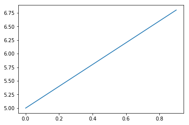

```python
import matplotlib.pyplot as plt
%matplotlib inline

y = x*2 + 5
plt.plot(x, y)
```

# Plotting a Sine Curve

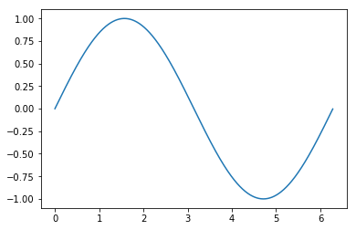

```python
from numpy import pi, sin

x = np.arange(0, 2*pi, 0.01)
y = sin(x)
plt.plot(x, y)
```

# Plotting a Histogram

- We can use the `hist()` function in `matplotlib` to plot a histogram

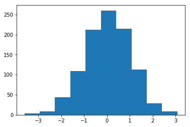

```python
# Generate some random data
data = np.random.randn(1000)

ax = plt.hist(data)
```

# Computing Histograms as Matrices

- The function `histogram()` in the `numpy` module will count frequencies into bins and return the result as a 2-dimensional array.

```python
np.histogram(data)
```

```
(array([  3,   9,  44, 109, 212, 260, 214, 113,  28,   8]),
 array([-3.61323249, -2.94380408, -2.27437568, -1.60494727, -0.93551886,
        -0.26609046,  0.40333795,  1.07276635,  1.74219476,  2.41162316,
         3.08105157]))
```

# Defining New Functions

```python
def squared(x):
    return x ** 2

squared(5)
```

```
25
```

# Local Variables

- Variables created inside functions are *local* to that function.
- They are not accessible to code outside of that function.

```python
def squared(x):
    result = x ** 2
    return result

squared(5)
```

```
25
```

```python
result
```

```
---------------------------------------------------------------------------
NameError                                 Traceback (most recent call last)
<ipython-input-2-0ac921c19f1a> in <module>
----> 1 result

NameError: name 'result' is not defined
```

# Functional Programming

- Functions are first-class citizens in Python.
- They can be passed around just like any other value.

```python
squared
```

```
<function __main__.squared>
```

```python
y = squared
y
```

```
<function __main__.squared>
```

```python
y(5)
```

```
25
```

# Mapping the Elements of a Collection

- We can apply a function to each element of a collection using the built-in function `map()`.
- This will work with any collection: list, set, tuple or string.
- This will take as an argument *another function* , and the list we want to apply it to.
- It will return the results of applying the function, as a list.

```python
list(map(squared, [1, 2, 3, 4]))
```

```
[1, 4, 9, 16]
```

# List Comprehensions

- Because this is such a common operation, Python has a special syntax to do the same thing, called a *list comprehension*.

```python
[squared(i) for i in [1, 2, 3, 4]]
```

```
[1, 4, 9, 16]
```

- If we want a set instead of a list we can use a set comprehension

```python
{squared(i) for i in [1, 2, 3, 4]}
```

```
{1, 4, 9, 16}
```

# Cartesian Product Using List Comprehensions

[figure not shown]

The [Cartesian product](https://en.wikipedia.org/wiki/Cartesian_product) of two collections $X = A \times B$ can be expressed by using multiple `for` statements in a comprehension.

```python
A = {'x', 'y', 'z'}
B = {1, 2, 3}
{(a,b) for a in A for b in B}
```

```
{('x', 1),
 ('x', 2),
 ('x', 3),
 ('y', 1),
 ('y', 2),
 ('y', 3),
 ('z', 1),
 ('z', 2),
 ('z', 3)}
```

# Cartesian Products with Other Collections

- The syntax for Cartesian products can be used with any collection type.

```python
first_names = ('Steve', 'John', 'Peter')
surnames = ('Smith', 'Doe')

[(first_name, surname) for first_name in first_names for surname in surnames]
```

```
[('Steve', 'Smith'),
 ('Steve', 'Doe'),
 ('John', 'Smith'),
 ('John', 'Doe'),
 ('Peter', 'Smith'),
 ('Peter', 'Doe')]
```

# Anonymous Function Literals

- We can also write *anonymous* functions.
- These are function literals, and do not necessarily have a name.
- They are called *lambda expressions* (after the $\lambda-$calculus).

```python
list(map(lambda x: x ** 2, [1, 2, 3, 4]))
```

```
[1, 4, 9, 16]
```

# Filtering Data

- We can filter a list by applying a *predicate* to each element of the list.
- A predicate is a function which takes a single argument, and returns a boolean value.
- `filter(p, X)` is equivalent to $\{ x : p(x) \wedge x \in X \}$ in set-builder notation.

```python
list(filter(lambda x: x > 0, [-5, 2, 3, -10, 0, 1]))
```

```
[2, 3, 1]
```

We can use both `filter()` and `map()` on other collections such as strings or sets.

```python
list(filter(lambda x: x != ' ', 'hello world'))
```

```
['h', 'e', 'l', 'l', 'o', 'w', 'o', 'r', 'l', 'd']
```

```python
list(map(ord, 'hello world'))
```

```
[104, 101, 108, 108, 111, 32, 119, 111, 114, 108, 100]
```

```python
list(filter(lambda x: x > 0, {-5, 2, 3, -10, 0, 1}))
```

```
[1, 2, 3]
```

# Filtering Using a List Comprehension

- Again, because this is such a common operation, we can use simpler syntax to say the same thing.
- We can express a filter using a list-comprehension by using the keyword `if`:

```python
data = [-5, 2, 3, -10, 0, 1]
[x for x in data if x > 0]
```

```
[2, 3, 1]
```

- We can also filter and then map in the same expression:

```python
from numpy import sqrt
[sqrt(x) for x in data if x > 0]
```

```
[1.4142135623730951, 1.7320508075688772, 1.0]
```

# The Reduce Function

- The `reduce()` function recursively applies another function to pairs of values over the entire list, resulting in a *single* return value.

```python
from functools import reduce
reduce(lambda x, y: x + y, [0, 1, 2, 3, 4, 5])
```

```
15
```

# Big Data

- The `map()` and `reduce()` functions form the basis of the map-reduce programming model.
- [Map-reduce](https://en.wikipedia.org/wiki/MapReduce) is the basis of modern highly-distributed large-scale computing frameworks.
- It is used in BigTable, Hadoop and Apache Spark.
- See [these examples in Python](https://spark.apache.org/examples.html) for Apache Spark.

# Reading Text Files

- To read an entire text file as a list of lines use the `readlines()` method of a file object.

```python
f = open('C:/readme.txt')
result = f.readlines()
f.close()
print(result)
```

```
['Hi\n', 'How are you?']
```

```python
# the first line
result[0]
```

```
'Hi\n'
```

To concatenate into a single string:

```python
single_string = ''.join(result)
```

```python
print(single_string)
single_string
```

```
Hi
How are you?
```

```
'Hi\nHow are you?'
```